```r
RATSL8S2 <- RATSL64S %>%
  mutate(baseline = RATS$WD1)
```

```r
fit <- lm(average ~ baseline + Group, data = RATSL8S2)
# Compute the analysis of variance table for the fitted model with anova()
anova(fit)
```

```
## Analysis of Variance Table
##
## Response: average
##           Df Sum Sq Mean Sq   F value   Pr(>F)
## baseline   1 253625  253625 1859.8201 1.57e-14 ***
## Group      2    879     439    3.2219  0.07586 .
## Residuals 12   1636     136
## ---
## Signif. codes:  0 '***' 0.001 '**' 0.01 '*' 0.05 '.' 0.1 ' ' 1
```

The data has 360 observations and 5 variables. The variables describe the sum of the scale measures levels, what treatment group the individual is assigned, and when the measures were collected.

```r
summary(BPRSL$bprs)
```

```
##    Min. 1st Qu.  Median    Mean 3rd Qu.    Max.
##   18.00   27.00   35.00   37.66   43.00   95.00
```

```r
summary(BPRSL$treatment)
```

```
##    Min. 1st Qu.  Median    Mean 3rd Qu.    Max.
##     1.0     1.0     1.5     1.5     2.0     2.0
```

```r
BPRSL$treatment <- factor(BPRSL$treatment)
```

The median of bprs rating is 35 and mean is 37.66. Some individuals diviate from this average signficantly, since the minimum of the rating is 18 and maximum 95.

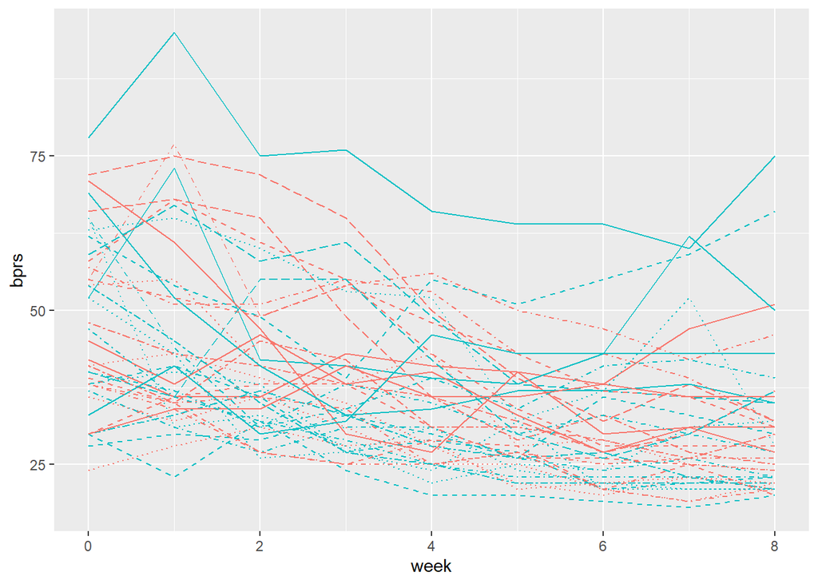

```r
BPRSL$subject <- factor(BPRSL$subject)
BPRSL$group <- factor(BPRSL$treatment)
ggplot(BPRSL, aes(x = week, y= bprs, linetype = subject, col = treatment)) +
  geom_line() +
   scale_linetype_manual(values = rep(1:10, times=4)) +

    theme(legend.position = "none") +
    scale_y_continuous(limits = c(min(BPRSL$bprs), max(BPRSL$bprs)))
```

In the blue are people who received treatment 2, and in red people received treatment 1. Maybe we get a clearer picture, if we plot these two groups individually by group:

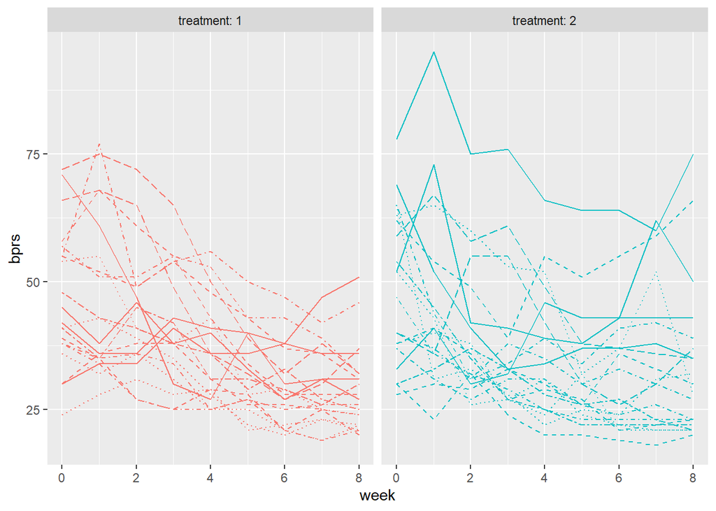

```r
BPRSL$subject <- factor(BPRSL$subject)
BPRSL$group <- factor(BPRSL$treatment)
ggplot(BPRSL, aes(x = week, y= bprs, linetype = subject, col = treatment)) +
  geom_line() +
   scale_linetype_manual(values = rep(1:10, times=4)) +
      facet_grid(. ~ treatment, labeller = label_both) +
      theme(legend.position = "none") +
    scale_y_continuous(limits = c(min(BPRSL$bprs), max(BPRSL$bprs)))
```

It may be difficult to distinguish a clear trend from these plots. For some people, it seems that treatment in group 1 or group 2 decreased BRPS points, but for some the treatment period did not.

```r
# create a regression model
BPRSL_reg <- lm(bprs ~ week + treatment, data = BPRSL)
# print out a summary of the model
summary(BPRSL_reg)
```

```
##
## Call:
## lm(formula = bprs ~ week + treatment, data = BPRSL)
##
## Residuals:
##     Min      1Q  Median      3Q     Max
## -22.454  -8.965  -3.196   7.002  50.244
##
## Coefficients:
##             Estimate Std. Error t value Pr(>|t|)
## (Intercept)  46.4539     1.3670  33.982   <2e-16 ***
## week         -2.2704     0.2524  -8.995   <2e-16 ***
## treatment2    0.5722     1.3034   0.439    0.661
## ---
## Signif. codes:  0 '***' 0.001 '**' 0.01 '*' 0.05 '.' 0.1 ' ' 1
##
## Residual standard error: 12.37 on 357 degrees of freedom
## Multiple R-squared:  0.1851, Adjusted R-squared:  0.1806
## F-statistic: 40.55 on 2 and 357 DF,  p-value: < 2.2e-16
```

From a simple regression model bprs = week + treatment, we see that the p-value for treatment2 is 0.661. Therefore, we cannot reject the null hypothesis that the coefficient of treatment2 is zero. Here we assume unrealistically indepence to the repeated measures of bprs for individuals.

```r
# access library lme4
library(lme4)
# Fitting a random intercept model allows the linear regression fit for each rat to differ # in intercept from other rats.
# Create a random intercept model
BPRSL_ref <- lmer(bprs ~ week + treatment + (1 | subject), data = BPRSL, REML = FALSE)
# Print the summary of the model
summary(BPRSL_ref)
```

```
## Linear mixed model fit by maximum likelihood  ['lmerMod']
## Formula: bprs ~ week + treatment + (1 | subject)
##    Data: BPRSL
##
##      AIC      BIC   logLik deviance df.resid
##   2748.7   2768.1  -1369.4   2738.7      355
##
## Scaled residuals:
##     Min      1Q  Median      3Q     Max
## -3.0481 -0.6749 -0.1361  0.4813  3.4855
##
## Random effects:
##  Groups   Name        Variance Std.Dev.
##  subject  (Intercept)  47.41    6.885
##  Residual             104.21   10.208
## Number of obs: 360, groups:  subject, 20
##
## Fixed effects:
##             Estimate Std. Error t value
## (Intercept)  46.4539     1.9090  24.334
## week         -2.2704     0.2084 -10.896
## treatment2    0.5722     1.0761   0.532
##
## Correlation of Fixed Effects:
##            (Intr) week
## week       -0.437
## treatment2 -0.282  0.000
```

```r
# create a random intercept and random slope model
BPRSL_ref1 <- lmer(bprs ~ week + treatment + (week | subject), data = BPRSL, REML = FALSE)
# Fitting a random intercept and random slope model allows the linear regression fits for each individual to differ in intercept but also in slope. This way it is possible to account for the individual differences in the rats' growth profiles, but also the   effect of time.
# print a summary of the model
summary(BPRSL_ref1)
```

```
## Linear mixed model fit by maximum likelihood  ['lmerMod']
## Formula: bprs ~ week + treatment + (week | subject)
##    Data: BPRSL
##
##      AIC      BIC   logLik deviance df.resid
##   2745.4   2772.6  -1365.7   2731.4      353
##
## Scaled residuals:
##     Min      1Q  Median      3Q     Max
## -2.8919 -0.6194 -0.0691  0.5531  3.7977
##
## Random effects:
##  Groups   Name        Variance Std.Dev. Corr
##  subject  (Intercept) 64.8222  8.0512
##           week         0.9609  0.9803   -0.51
##  Residual             97.4304  9.8707
## Number of obs: 360, groups:  subject, 20
##
## Fixed effects:
##             Estimate Std. Error t value
## (Intercept)  46.4539     2.1052  22.066
## week         -2.2704     0.2977  -7.626
## treatment2    0.5722     1.0405   0.550
##
## Correlation of Fixed Effects:
##            (Intr) week
## week       -0.582
## treatment2 -0.247  0.000
```

```r
# perform an ANOVA test on the two models
anova(BPRSL_ref1, BPRSL_ref)
```

```
## Data: BPRSL
## Models:
## BPRSL_ref: bprs ~ week + treatment + (1 | subject)
## BPRSL_ref1: bprs ~ week + treatment + (week | subject)
##            Df    AIC    BIC  logLik deviance  Chisq Chi Df Pr(>Chisq)
## BPRSL_ref   5 2748.7 2768.1 -1369.4   2738.7
## BPRSL_ref1  7 2745.4 2772.6 -1365.7   2731.4 7.2721      2    0.02636 *
## ---
## Signif. codes:  0 '***' 0.001 '**' 0.01 '*' 0.05 '.' 0.1 ' ' 1
```

```r
# create a random intercept and random slope model
# Add a interaction term
BPRSL_ref2 <- lmer(bprs ~ week * treatment + (week | subject), data = BPRSL, REML = FALSE)
# print a summary of the model
summary(BPRSL_ref2)
```

```
## Linear mixed model fit by maximum likelihood  ['lmerMod']
## Formula: bprs ~ week * treatment + (week | subject)
##    Data: BPRSL
##
##      AIC      BIC   logLik deviance df.resid
##   2744.3   2775.4  -1364.1   2728.3      352
##
## Scaled residuals:
##     Min      1Q  Median      3Q     Max
## -3.0512 -0.6271 -0.0768  0.5288  3.9260
##
## Random effects:
##  Groups   Name        Variance Std.Dev. Corr
##  subject  (Intercept) 64.9964  8.0620
##           week         0.9687  0.9842   -0.51
##  Residual             96.4707  9.8220
## Number of obs: 360, groups:  subject, 20
##
## Fixed effects:
##                 Estimate Std. Error t value
## (Intercept)      47.8856     2.2521  21.262
## week             -2.6283     0.3589  -7.323
## treatment2       -2.2911     1.9090  -1.200
## week:treatment2   0.7158     0.4010   1.785
##
## Correlation of Fixed Effects:
##             (Intr) week   trtmn2
## week        -0.650
## treatment2  -0.424  0.469
## wek:trtmnt2  0.356 -0.559 -0.840
```

```r
# perform an ANOVA test on the two models
anova(BPRSL_ref2, BPRSL_ref1)
```

```
## Data: BPRSL
## Models:
## BPRSL_ref1: bprs ~ week + treatment + (week | subject)
## BPRSL_ref2: bprs ~ week * treatment + (week | subject)
##            Df    AIC    BIC  logLik deviance  Chisq Chi Df Pr(>Chisq)
## BPRSL_ref1  7 2745.4 2772.6 -1365.7   2731.4
## BPRSL_ref2  8 2744.3 2775.4 -1364.1   2728.3 3.1712      1    0.07495 .
## ---
## Signif. codes:  0 '***' 0.001 '**' 0.01 '*' 0.05 '.' 0.1 ' ' 1
```

Here, I created a random intercept and random slope model with an interaction term of week and treatment, measuring how these terms affect together bprs value.

The chi-squared statistics is low (3.17). P-value of the likelihood ratio test between BPRSL_ref1 and BPRS_ref2 is 0.07495, indicating that on 10 % significance level, the model increases fit. However, on 5 % significance level, we cannot make this conclusion.

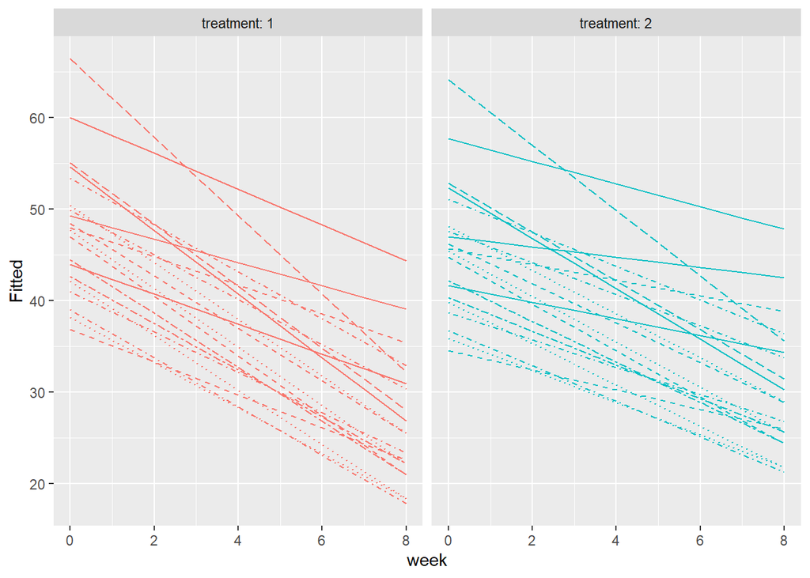

```r
# Create a vector of the fitted values
Fitted <- fitted(BPRSL_ref2)
# Create a new column fitted to BPRSL
BPRSL <- BPRSL %>%
  mutate(Fitted)
ggplot(BPRSL, aes(x = week, y= Fitted, linetype = subject, col = treatment)) +
  geom_line() +
   scale_linetype_manual(values = rep(1:10, times=4)) +
      facet_grid(. ~ treatment, labeller = label_both) +
      theme(legend.position = "none") +
    scale_y_continuous(limits = c(min(BPRSL$Fitted), max(BPRSL$Fitted)))
```